Skip to content

# Fitting

```python
from __future__ import annotations

import matplotlib.pyplot as plt
import numpy as np
import pandas as pd

from example_models import get_linear_chain_2v
from mxlpy import Simulator, fit, make_protocol, plot
```

from __future__ import annotations import matplotlib.pyplot as plt import numpy as np import pandas as pd from example_models import get_linear_chain_2v from mxlpy import Simulator, fit, make_protocol, plot

## Fitting

Almost every model at some point needs to be fitted to experimental data to be **validated**.

[figure not shown]

*mxlpy* offers highly customisable local and global routines for fitting either **time series** or **steady-states**.

The entire set of currently supported routines is

Single model, single data

- `steady_state`
- `time_course`
- `protocol_time_course`

Single model, single data, multiple initial guesses

- `group_steady_state`
- `group_time_course`
- `group_protocol_time_course`

Multiple model, single data

- `ensemble_steady_state`
- `ensemble_time_course`
- `ensemble_protocol_time_course`

A carousel is a special case of an ensemble, where the general structure (e.g. stoichiometries) is the same, while the reactions kinetics can vary

- `carousel_steady_state`
- `carousel_time_course`
- `carousel_protocol_time_course`

Multiple model, multiple data

- `joint_steady_state`
- `joint_time_course`
- `joint_protocol_time_course`

Multiple model, multiple data, multiple methods

Here we also allow to run different methods (e.g. steady-state vs time courses) for each combination of model:data.

- `joint_mixed`

## Minimizers

- LocalScipyMinimizer, including common methods such as Nelder-Mead or L-BFGS-B
- GlobalScipyMinimizer, including common methods such as basin hopping or dual annealing

For this tutorial we are going to use the `fit` module to optimise our parameter values and the `plot` module to plot some results.

Let's get started!

## Creating synthetic data

Normally, you would fit your model to experimental data.  
Here, for the sake of simplicity, we will generate some synthetic data.

Checkout the basics tutorial if you need a refresher on building and simulating models.

```python
# As a small trick, let's define a variable for the model function
# That way, we can re-use it all over the file and easily replace
# it with another model
model_fn = get_linear_chain_2v

res = (
    Simulator(model_fn())
    .update_parameters({"k1": 1.0, "k2": 2.0, "k3": 1.0})
    .simulate_time_course(np.linspace(0, 10, 101))
    .get_result()
    .unwrap_or_err()
).get_combined()

fig, ax = plot.lines(res)
ax.set(xlabel="time / a.u.", ylabel="Conc. & Flux / a.u.")
plt.show()
```

# As a small trick, let's define a variable for the model function # That way, we can re-use it all over the file and easily replace # it with another model model_fn = get_linear_chain_2v res = ( Simulator(model_fn()) .update_parameters({"k1": 1.0, "k2": 2.0, "k3": 1.0}) .simulate_time_course(np.linspace(0, 10, 101)) .get_result() .unwrap_or_err() ).get_combined() fig, ax = plot.lines(res) ax.set(xlabel="time / a.u.", ylabel="Conc. & Flux / a.u.") plt.show()

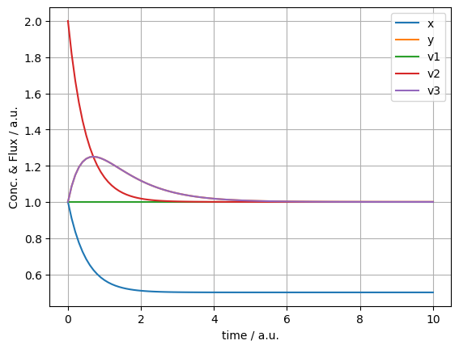

```python
# Create data for protocol fitting
protocol = make_protocol(
    [
        (1, {"k1": 1.0}),
        (1, {"k1": 2.0}),
        (1, {"k1": 1.0}),
    ]
)

res_protocol = (
    Simulator(model_fn())
    .update_parameters({"k1": 1.0, "k2": 2.0, "k3": 1.0})
    .simulate_protocol(
        protocol,
        time_points_per_step=10,
    )
    .get_result()
    .unwrap_or_err()
).get_combined()

fig, ax = plot.lines(res_protocol)
ax.set(xlabel="time / a.u.", ylabel="Conc. & Flux / a.u.")
plt.show()
```

# Create data for protocol fitting protocol = make_protocol( [ (1, {"k1": 1.0}), (1, {"k1": 2.0}), (1, {"k1": 1.0}), ] ) res_protocol = ( Simulator(model_fn()) .update_parameters({"k1": 1.0, "k2": 2.0, "k3": 1.0}) .simulate_protocol( protocol, time_points_per_step=10, ) .get_result() .unwrap_or_err() ).get_combined() fig, ax = plot.lines(res_protocol) ax.set(xlabel="time / a.u.", ylabel="Conc. & Flux / a.u.") plt.show()

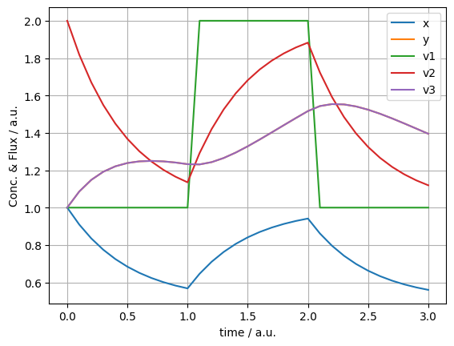

### Steady-states

For the steady-state fit we need two inputs:

1. the steady state data, which we supply as a `pandas.Series`
2. an initial parameter guess

The fitting routine will compare all data contained in that series to the model output.

> Note that the data both contains concentrations and fluxes!

```python
data = res.iloc[-1]
data.head()
```

data = res.iloc[-1] data.head()

```
x     0.500000
y     1.000045
v1    1.000000
v2    1.000000
v3    1.000045
Name: 10.0, dtype: float64
```

```python
fit_result = fit.steady_state(
    model_fn(),
    p0={"k1": 1.038, "k2": 1.87, "k3": 1.093},
    data=res.iloc[-1],
    minimizer=fit.LocalScipyMinimizer(),
).unwrap_or_err()

fit_result.best_pars
```

fit_result = fit.steady_state( model_fn(), p0={"k1": 1.038, "k2": 1.87, "k3": 1.093}, data=res.iloc[-1], minimizer=fit.LocalScipyMinimizer(), ).unwrap_or_err() fit_result.best_pars

```
{'k1': np.float64(1.0000163007534455),
 'k2': np.float64(2.000039927960906),
 'k3': np.float64(0.9999764134803077)}
```

If only some of the data is required, you can use a subset of it.  
The fitting routine will only try to fit concentrations and fluxes contained in that series.

```python
fit_result = fit.steady_state(
    model_fn(),
    p0={"k1": 1.038, "k2": 1.87, "k3": 1.093},
    data=data.loc[["x", "y"]],
    minimizer=fit.LocalScipyMinimizer(),
).unwrap_or_err()
fit_result.best_pars
```

fit_result = fit.steady_state( model_fn(), p0={"k1": 1.038, "k2": 1.87, "k3": 1.093}, data=data.loc[["x", "y"]], minimizer=fit.LocalScipyMinimizer(), ).unwrap_or_err() fit_result.best_pars

```
{'k1': np.float64(1.038), 'k2': np.float64(1.87), 'k3': np.float64(1.093)}
```

> By default, mxlpy will apply standard scaling to all fitting functions.

Specifically, it will calculate `loss_fn(data - data.mean()) / data.std()`, `(pred - data.mean()) / data.std())`.

To turn off this behaviour, set `standard_scale=False` in the fit functions

```python
fit_result = fit.steady_state(
    model_fn(),
    p0={"k1": 1.038, "k2": 1.87, "k3": 1.093},
    data=data.loc[["x", "y"]],
    minimizer=fit.LocalScipyMinimizer(),
    standard_scale=False,  # opt-out of standard scaling
).unwrap_or_err()
fit_result.best_pars
```

fit_result = fit.steady_state( model_fn(), p0={"k1": 1.038, "k2": 1.87, "k3": 1.093}, data=data.loc[["x", "y"]], minimizer=fit.LocalScipyMinimizer(), standard_scale=False, # opt-out of standard scaling ).unwrap_or_err() fit_result.best_pars

```
{'k1': np.float64(0.9829148508538471),
 'k2': np.float64(1.9658250996687356),
 'k3': np.float64(0.982870968741833)}
```

### Time course

For the time course fit we need again need two inputs

1. the time course data, which we supply as a `pandas.DataFrame`
2. an initial parameter guess

The fitting routine will create data at every time points specified in the `DataFrame` and compare all of them.

Other than that, the same rules of the steady-state fitting apply.

```python
fit_result = fit.time_course(
    model_fn(),
    p0={"k1": 1.038, "k2": 1.87, "k3": 1.093},
    data=res,
    minimizer=fit.LocalScipyMinimizer(),
).unwrap_or_err()

fit_result.best_pars
```

fit_result = fit.time_course( model_fn(), p0={"k1": 1.038, "k2": 1.87, "k3": 1.093}, data=res, minimizer=fit.LocalScipyMinimizer(), ).unwrap_or_err() fit_result.best_pars

```
{'k1': np.float64(1.0000000969921656),
 'k2': np.float64(2.0000007689750547),
 'k3': np.float64(1.000000018337354)}
```

## Protocol time courses

For the protocol time course fit we need three inputs

1. an initial parameter guess
2. the time course data, which we supply as a `pandas.DataFrame`
3. the protocol, which we supply as a `pandas.DataFrame`

> Note that the parameter given by the protocol cannot be fitted anymore

You can use the `make_protocol` function to create a protocol (see above).

The protocol `DataFrame` should preferrably use a `pd.TimedeltaIndex` and is interpreted as "use the parameter values of that row **until** the given end point."

> Here a second corresponds to a unit of simulation time, regardless of model time scale.

`mxlpy` will attempt to convert other indices, again assuming that a second in your data corresponds to a second of simulation time.

```python
protocol
```

protocol

| Timedelta | k1 |
| --- | --- |
| 0 days 00:00:01 | 1.0 |
| 0 days 00:00:02 | 2.0 |
| 0 days 00:00:03 | 1.0 |

```python
fit_result = fit.protocol_time_course(
    model_fn(),
    p0={"k2": 1.87, "k3": 1.093},  # note that k1 is given by the protocol
    data=res_protocol,
    protocol=protocol,
    minimizer=fit.LocalScipyMinimizer(),
).unwrap_or_err()

fit_result.best_pars
```

fit_result = fit.protocol_time_course( model_fn(), p0={"k2": 1.87, "k3": 1.093}, # note that k1 is given by the protocol data=res_protocol, protocol=protocol, minimizer=fit.LocalScipyMinimizer(), ).unwrap_or_err() fit_result.best_pars

```
{'k2': np.float64(1.9999998987861942), 'k3': np.float64(1.0000002296553467)}
```

## Group fitting

`mxlpy` supports group fitting, which is a **single-model single data** approach, where different initial conditions are fitted independently.

```python
group_fit = fit.group_steady_state(
    model_fn(),
    data=res.iloc[-1],
    p0=pd.DataFrame(
        {
            "k1": [1.037, 1.038, 1.039],
            "k2": [1.86, 1.87, 1.88],
            "k3": [1.092, 1.093, 1.094],
        }
    ),
    minimizer=fit.LocalScipyMinimizer(tol=1e-6),
)
```

group_fit = fit.group_steady_state( model_fn(), data=res.iloc[-1], p0=pd.DataFrame( { "k1": [1.037, 1.038, 1.039], "k2": [1.86, 1.87, 1.88], "k3": [1.092, 1.093, 1.094], } ), minimizer=fit.LocalScipyMinimizer(tol=1e-6), )

### Time course

Time course fits are adjusted just the same

```python
group_fit = fit.group_time_course(
    model_fn(),
    data=res,
    p0=pd.DataFrame(
        {
            "k1": [1.037, 1.038, 1.039],
            "k2": [1.86, 1.87, 1.88],
            "k3": [1.092, 1.093, 1.094],
        }
    ),
    minimizer=fit.LocalScipyMinimizer(tol=1e-6),
)
```

group_fit = fit.group_time_course( model_fn(), data=res, p0=pd.DataFrame( { "k1": [1.037, 1.038, 1.039], "k2": [1.86, 1.87, 1.88], "k3": [1.092, 1.093, 1.094], } ), minimizer=fit.LocalScipyMinimizer(tol=1e-6), )

### Protocol time course

As are protocol time courses

```python
group_fit = fit.group_protocol_time_course(
    model_fn(),
    data=res_protocol,
    protocol=protocol,
    p0=pd.DataFrame(
        {
            "k1": [1.037, 1.038, 1.039],
            "k2": [1.86, 1.87, 1.88],
            "k3": [1.092, 1.093, 1.094],
        }
    ),
    minimizer=fit.LocalScipyMinimizer(tol=1e-6),
)
```

group_fit = fit.group_protocol_time_course( model_fn(), data=res_protocol, protocol=protocol, p0=pd.DataFrame( { "k1": [1.037, 1.038, 1.039], "k2": [1.86, 1.87, 1.88], "k3": [1.092, 1.093, 1.094], } ), minimizer=fit.LocalScipyMinimizer(tol=1e-6), )

### Combining with monte-carlo approaches

An especially useful combination is combining group fitting with the monte-carlo capabilities of `mxlpy` to quickly get multiple fits from randomly selected initial conditions

```python
from mxlpy.distributions import Uniform, sample

group_fit = fit.group_steady_state(
    model_fn(),
    data=res.iloc[-1],
    p0=sample(
        {
            "k1": Uniform(1.037, 1.039),
            "k2": Uniform(1.86, 1.88),
            "k3": Uniform(1.092, 1.094),
        },
        n=3,
    ),
    minimizer=fit.LocalScipyMinimizer(tol=1e-6),
)
```

from mxlpy.distributions import Uniform, sample group_fit = fit.group_steady_state( model_fn(), data=res.iloc[-1], p0=sample( { "k1": Uniform(1.037, 1.039), "k2": Uniform(1.86, 1.88), "k3": Uniform(1.092, 1.094), }, n=3, ), minimizer=fit.LocalScipyMinimizer(tol=1e-6), )

```python
group_fit.get_losses()
```

group_fit.get_losses()

```
0    0.000074
1    0.000074
2    0.000074
dtype: float64
```

```python
best_model = group_fit.get_best_fit().model
```

best_model = group_fit.get_best_fit().model

## Ensemble fitting

`mxlpy` supports ensemble fitting, which is a **multi-model single data** approach, where shared parameters will be applied to all models at the same time.

Here you supply an iterable of models instead of just one, otherwise the API stays the same.

```python
ensemble_fit = fit.ensemble_steady_state(
    [
        model_fn(),
        model_fn(),
    ],
    data=res.iloc[-1],
    p0={"k1": 1.038, "k2": 1.87, "k3": 1.093},
    minimizer=fit.LocalScipyMinimizer(tol=1e-6),
)
```

ensemble_fit = fit.ensemble_steady_state( [ model_fn(), model_fn(), ], data=res.iloc[-1], p0={"k1": 1.038, "k2": 1.87, "k3": 1.093}, minimizer=fit.LocalScipyMinimizer(tol=1e-6), )

To get the best fitting model, you can use `get_best_fit` on the ensemble fit

```python
fit_result = ensemble_fit.get_best_fit()
```

fit_result = ensemble_fit.get_best_fit()

And you can of course also access all other fits

```python
[i.loss for i in ensemble_fit.fits]
```

[i.loss for i in ensemble_fit.fits]

```
[np.float64(7.514230040132784e-05), np.float64(7.514230040132784e-05)]
```

### Time course

Time course fits are adjusted just the same

```python
ensemble_fit = fit.ensemble_time_course(
    [
        model_fn(),
        model_fn(),
    ],
    data=res,
    p0={"k1": 1.038, "k2": 1.87, "k3": 1.093},
    minimizer=fit.LocalScipyMinimizer(tol=1e-6),
)
```

ensemble_fit = fit.ensemble_time_course( [ model_fn(), model_fn(), ], data=res, p0={"k1": 1.038, "k2": 1.87, "k3": 1.093}, minimizer=fit.LocalScipyMinimizer(tol=1e-6), )

### Protocol time course

As are protocol time courses

```python
ensemble_fit = fit.ensemble_protocol_time_course(
    [
        model_fn(),
        model_fn(),
    ],
    data=res_protocol,
    protocol=protocol,
    p0={"k2": 1.87, "k3": 1.093},  # note that k1 is given by the protocol
    minimizer=fit.LocalScipyMinimizer(tol=1e-6),
)
```

ensemble_fit = fit.ensemble_protocol_time_course( [ model_fn(), model_fn(), ], data=res_protocol, protocol=protocol, p0={"k2": 1.87, "k3": 1.093}, # note that k1 is given by the protocol minimizer=fit.LocalScipyMinimizer(tol=1e-6), )

## Joint fitting

Next, we support joint fitting, which is a combined **multi-model multi-data** approach, where shared parameters will be applied to all models at the same time

```python
fit.joint_steady_state(
    [
        fit.FitSettings(model=model_fn(), data=res.iloc[-1]),
        fit.FitSettings(model=model_fn(), data=res.iloc[-1]),
    ],
    p0={"k1": 1.038, "k2": 1.87, "k3": 1.093},
    minimizer=fit.LocalScipyMinimizer(tol=1e-6),
)
```

fit.joint_steady_state( [ fit.FitSettings(model=model_fn(), data=res.iloc[-1]), fit.FitSettings(model=model_fn(), data=res.iloc[-1]), ], p0={"k1": 1.038, "k2": 1.87, "k3": 1.093}, minimizer=fit.LocalScipyMinimizer(tol=1e-6), )

```
Result(value=JointFit(
  best_pars={'k1': np.float64(1.038), 'k2': np.float64(1.87), 'k3': np.float64(1.093)},
  loss=np.float64(0.397958351965744)
))
```

```python
fit.joint_time_course(
    [
        fit.FitSettings(model=model_fn(), data=res),
        fit.FitSettings(model=model_fn(), data=res),
    ],
    p0={"k1": 1.038, "k2": 1.87, "k3": 1.093},
    minimizer=fit.LocalScipyMinimizer(tol=1e-6),
)
```

fit.joint_time_course( [ fit.FitSettings(model=model_fn(), data=res), fit.FitSettings(model=model_fn(), data=res), ], p0={"k1": 1.038, "k2": 1.87, "k3": 1.093}, minimizer=fit.LocalScipyMinimizer(tol=1e-6), )

```
Result(value=JointFit(
  best_pars={
    'k1': np.float64(0.9999999762596696),
    'k2': np.float64(2.000000126880531),
    'k3': np.float64(0.9999999033775664)
  },
  loss=np.float64(1.1931053813152017e-06)
))
```

```python
fit.joint_protocol_time_course(
    [
        fit.FitSettings(model=model_fn(), data=res_protocol, protocol=protocol),
        fit.FitSettings(model=model_fn(), data=res_protocol, protocol=protocol),
    ],
    p0={"k2": 1.87, "k3": 1.093},
    minimizer=fit.LocalScipyMinimizer(tol=1e-6),
)
```

fit.joint_protocol_time_course( [ fit.FitSettings(model=model_fn(), data=res_protocol, protocol=protocol), fit.FitSettings(model=model_fn(), data=res_protocol, protocol=protocol), ], p0={"k2": 1.87, "k3": 1.093}, minimizer=fit.LocalScipyMinimizer(tol=1e-6), )

```
Result(value=JointFit(
  best_pars={'k2': np.float64(2.0000002702778183), 'k3': np.float64(0.999999947877055)},
  loss=np.float64(8.073328249907286e-07)
))
```

## Mixed joint fitting

Lastly, we support mixed-joint fitting, where each analysis takes it's own residual function to allow fitting both time series and steady-state data for multiple models at the same time.

```python
fit.joint_mixed(
    [
        fit.MixedSettings(
            model=model_fn(),
            data=res.iloc[-1],
            residual_fn=fit.steady_state_residual,
        ),
        fit.MixedSettings(
            model=model_fn(),
            data=res,
            residual_fn=fit.time_course_residual,
        ),
        fit.MixedSettings(
            model=model_fn(),
            data=res_protocol,
            protocol=protocol,
            residual_fn=fit.protocol_time_course_residual,
        ),
    ],
    p0={"k2": 1.87, "k3": 1.093},
    minimizer=fit.LocalScipyMinimizer(tol=1e-6),
)
```

fit.joint_mixed( [ fit.MixedSettings( model=model_fn(), data=res.iloc[-1], residual_fn=fit.steady_state_residual, ), fit.MixedSettings( model=model_fn(), data=res, residual_fn=fit.time_course_residual, ), fit.MixedSettings( model=model_fn(), data=res_protocol, protocol=protocol, residual_fn=fit.protocol_time_course_residual, ), ], p0={"k2": 1.87, "k3": 1.093}, minimizer=fit.LocalScipyMinimizer(tol=1e-6), )

```
Result(value=JointFit(
  best_pars={'k2': np.float64(1.87), 'k3': np.float64(1.093)},
  loss=np.float64(1.1417581457299972)
))
```

## First finish line

With that you now know most of what you will need from a day-to-day basis about fitting in mxlpy.  
Congratulations!

## Advanced topics / customisation

All fitting routines internally are build in a way that they will call a tree of functions.

- `minimizer`
  - `residual_fn`
    - `integrator`
    - `loss_fn`

You can therefore use dependency injection to overwrite the minimisation function, the loss function, the residual function and the integrator if need be.

```python
from functools import partial
from typing import cast

from mxlpy.integrators import Scipy
```

from functools import partial from typing import cast from mxlpy.integrators import Scipy

## Parameterising scipy optimise

```python
optimizer = fit.LocalScipyMinimizer(tol=1e-6, method="Nelder-Mead")
```

optimizer = fit.LocalScipyMinimizer(tol=1e-6, method="Nelder-Mead")

### Custom loss function

You can change the loss function that is being passed to the minimsation function using the `loss_fn` keyword.  
Depending on the use case (time course vs steady state) this function will be passed two pandas `DataFrame`s or `Series`.

```python
def mean_absolute_error(
    x: pd.DataFrame | pd.Series,
    y: pd.DataFrame | pd.Series,
) -> float:
    """Mean absolute error between two dataframes."""
    return cast(float, np.mean(np.abs(x - y)))


(
    fit.time_course(
        model_fn(),
        p0={"k1": 1.038, "k2": 1.87, "k3": 1.093},
        data=res,
        loss_fn=mean_absolute_error,
        minimizer=fit.LocalScipyMinimizer(),
    )
    .unwrap_or_err()
    .best_pars
)
```

def mean_absolute_error( x: pd.DataFrame | pd.Series, y: pd.DataFrame | pd.Series, ) -> float: """Mean absolute error between two dataframes.""" return cast(float, np.mean(np.abs(x - y))) ( fit.time_course( model_fn(), p0={"k1": 1.038, "k2": 1.87, "k3": 1.093}, data=res, loss_fn=mean_absolute_error, minimizer=fit.LocalScipyMinimizer(), ) .unwrap_or_err() .best_pars )

```
{'k1': np.float64(1.0000000423435782),
 'k2': np.float64(2.000000030636909),
 'k3': np.float64(1.0000001121604776)}
```

### Custom integrator

You can change the default integrator to an integrator of your choice by partially application of the class of any of the existing ones.

Here, for example, we choose the `Scipy` solver suite and set the default relative and absolute tolerances to `1e-6` respectively.

```python
(
    fit.time_course(
        model_fn(),
        p0={"k1": 1.038, "k2": 1.87, "k3": 1.093},
        data=res,
        integrator=partial(Scipy, rtol=1e-6, atol=1e-6),
        minimizer=fit.LocalScipyMinimizer(),
    )
    .unwrap_or_err()
    .best_pars
)
```

( fit.time_course( model_fn(), p0={"k1": 1.038, "k2": 1.87, "k3": 1.093}, data=res, integrator=partial(Scipy, rtol=1e-6, atol=1e-6), minimizer=fit.LocalScipyMinimizer(), ) .unwrap_or_err() .best_pars )

```
{'k1': np.float64(1.0000001588874141),
 'k2': np.float64(2.000000502795258),
 'k3': np.float64(1.0000001158476401)}
```